# 05_rat_keto_vs_ctrl

Gauri Agrawal

2025-10-10

1. Load dataset using read.table() function and header=T/row.names=1 arguments.

```r
rat_dataset = read.table("/Users/gauri1399/Desktop/Classes/Sem 3/Gene expression/Lab 5/rat_KD.txt", header=T, row.names=1)
```

2. First log2 the data, then use the Student’s t-test function in the notes to calculate the changing genes between the control diet and ketogenic diet classes.

```r
log2_rat_dataset = log2(rat_dataset+1)

# Extract the column name to separate them into ketogenic and control diet
diet_type = colnames(rat_dataset)
control_cols = grep("control.diet", diet_type, value = TRUE)
keto_cols = grep("ketogenic.diet", diet_type, value = TRUE)

t_test_pvalues = apply(log2_rat_dataset, 1, function(gene_expr) {
  control_vals = as.numeric(gene_expr[control_cols])
  keto_vals = as.numeric(gene_expr[keto_cols])

  # Student’s t-test with equal variance assumption
  t.test(control_vals, keto_vals, var.equal = TRUE)$p.value
})
```

3. Plot a histogram of the p-values and report how many probesets have a p<.05 and p<.01. Then divide an alpha of 0.05 by the total number of probesets and report how many probesets have a p-value less than this value. This is a very conservative p-value thresholding method to account for multiple testing called the Bonferroni correction

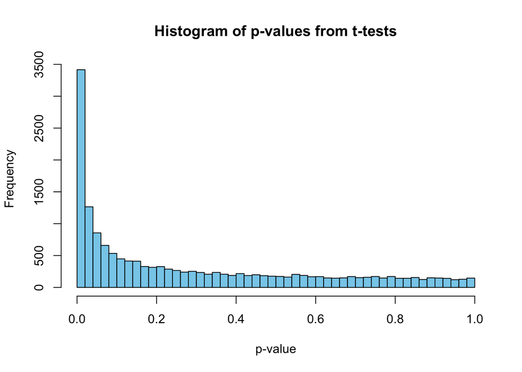

```r
hist(t_test_pvalues,
     breaks = 50,
     col = "skyblue",
     main = "Histogram of p-values from t-tests",
     xlab = "p-value",
     ylab = "Frequency")
```

```r
# Find p values less than 0.05 and 0.01
p_0.05 = sum(t_test_pvalues < 0.05, na.rm = TRUE)
p_0.01 = sum(t_test_pvalues < 0.01, na.rm = TRUE)

# Print the values
cat("Number of probesets with p < 0.05:", p_0.05, "\n")
```

```
## Number of probesets with p < 0.05: 5159
```

```r
cat("Number of probesets with p < 0.01:", p_0.01, "\n")
```

```
## Number of probesets with p < 0.01: 2420
```

```r
# Find the Bonferroni alpha
num_probesets = length(t_test_pvalues)
bonferroni_alpha = 0.05 / num_probesets
num_bonferroni = sum(t_test_pvalues < bonferroni_alpha, na.rm = TRUE)

# Print the probesets less than Bonferroni alpha
cat("Bonferroni-corrected alpha:", bonferroni_alpha, "\n")
```

```
## Bonferroni-corrected alpha: 3.140112e-06
```

```r
cat("Number of probesets with p <", bonferroni_alpha, ":", num_bonferroni, "\n")
```

```
## Number of probesets with p < 3.140112e-06 : 12
```

4. Next calculate the mean for each gene, and calculate the fold change between the groups (control vs. ketogenic diet).

```r
# Calculate mean for each gene
gene_means = rowMeans(log2_rat_dataset, na.rm = TRUE)
head(gene_means)
```

```
##  AFFX-BioB-5_at  AFFX-BioB-M_at  AFFX-BioB-3_at  AFFX-BioC-5_at  AFFX-BioC-3_at
##        6.471981        6.750243        5.482963        7.564226        6.812454
## AFFX-BioDn-5_at
##        7.360443
```

```r
# Calculate fold change
keto_log2_mean = rowMeans(log2_rat_dataset[keto_cols], na.rm = TRUE)
control_log2_mean = rowMeans(log2_rat_dataset[control_cols], na.rm = TRUE)

log2_fold_change = keto_log2_mean - control_log2_mean
fold_change = 2 ^ log2_fold_change

# Print values
cat("\n Mean for each gene:\n")
```

```
##
##  Mean for each gene:
```

```r
print(head(gene_means))
```

```
##  AFFX-BioB-5_at  AFFX-BioB-M_at  AFFX-BioB-3_at  AFFX-BioC-5_at  AFFX-BioC-3_at
##        6.471981        6.750243        5.482963        7.564226        6.812454
## AFFX-BioDn-5_at
##        7.360443
```

```r
cat("\n Mean for keto group:\n")
```

```
##
##  Mean for keto group:
```

```r
print(head(keto_log2_mean))
```

```
##  AFFX-BioB-5_at  AFFX-BioB-M_at  AFFX-BioB-3_at  AFFX-BioC-5_at  AFFX-BioC-3_at
##        6.543438        7.001069        5.658533        7.678885        6.997850
## AFFX-BioDn-5_at
##        7.471803
```

```r
cat("\n Mean for control group:\n")
```

```
##
##  Mean for control group:
```

```r
print(head(control_log2_mean))
```

```
##  AFFX-BioB-5_at  AFFX-BioB-M_at  AFFX-BioB-3_at  AFFX-BioC-5_at  AFFX-BioC-3_at
##        6.412433        6.541222        5.336654        7.468676        6.657958
## AFFX-BioDn-5_at
##        7.267644
```

```r
cat("\n Log2 Fold Change:\n")
```

```
##
##  Log2 Fold Change:
```

```r
print(head(log2_fold_change))
```

```
##  AFFX-BioB-5_at  AFFX-BioB-M_at  AFFX-BioB-3_at  AFFX-BioC-5_at  AFFX-BioC-3_at
##       0.1310048       0.4598478       0.3218786       0.2102094       0.3398928
## AFFX-BioDn-5_at
##       0.2041595
```

```r
cat("\nFold Change:\n")
```

```
##
## Fold Change:
```

```r
print(head(fold_change))
```

```
##  AFFX-BioB-5_at  AFFX-BioB-M_at  AFFX-BioB-3_at  AFFX-BioC-5_at  AFFX-BioC-3_at
##        1.095056        1.375397        1.249957        1.156856        1.265663
## AFFX-BioDn-5_at
##        1.152015
```

5. What is the maximum and minimum fold change value, please report on the linear scale? Now report the probesets with a p-value less than the Bonferroni threshold you used in question 4 and |fold change|>2

```r
# Find the maximum and minimum fold change value
max(fold_change)
```

```
## [1] 8.363878
```

```r
min(fold_change)
```

```
## [1] 0.02312243
```

```r
# Find significant p values
significant_index = which(t_test_pvalues < bonferroni_alpha & abs(log2_fold_change) > 1)
significant_genes = rownames(log2_rat_dataset)[significant_index]
print(significant_genes)
```

```
## [1] "1367553_x_at" "1370239_at"   "1370240_x_at" "1371102_x_at" "1371245_a_at"
## [6] "1388608_x_at"
```

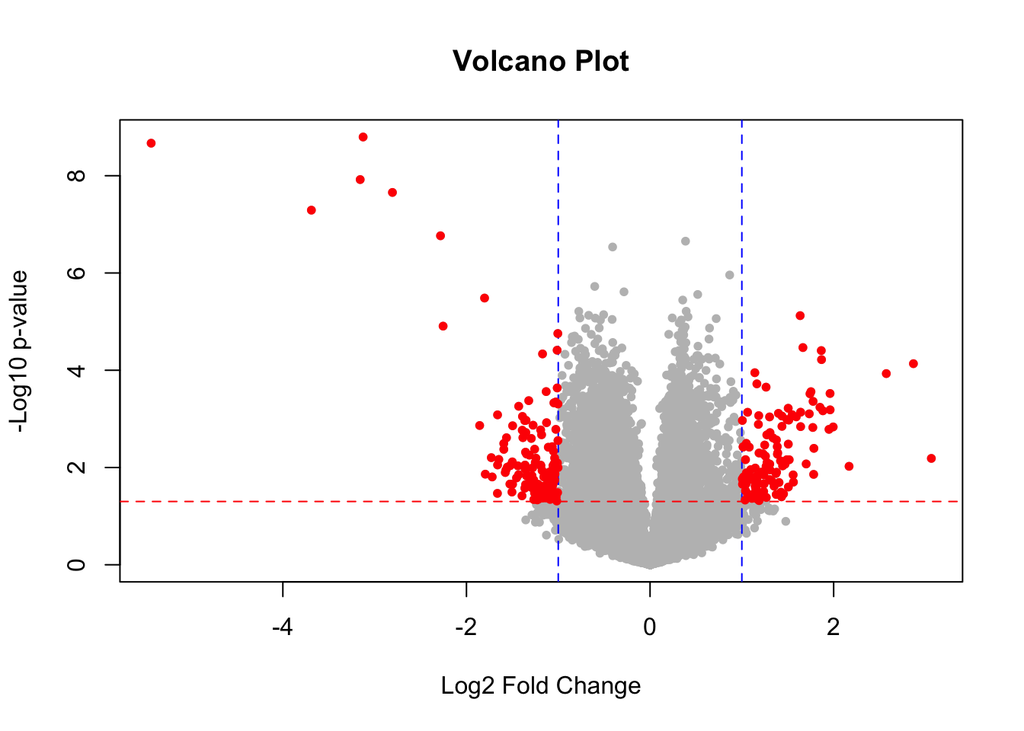

```r
log10_pvalues = -log10(t_test_pvalues)

# Plot the graph
plot(log2_fold_change, log10_pvalues,
     pch = 20, col = "grey",
     xlab = "Log2 Fold Change",
     ylab = "-Log10 p-value",
     main = "Volcano Plot")

# Add vertical and horizontal lines at fold change = ±1 (log2 scale)
abline(v = c(-1, 1), col = "blue", lty = 2)
abline(h = -log10(0.05), col = "red", lty = 2)

# Highlight significant points
sig_index <- which(t_test_pvalues < 0.05 & abs(log2_fold_change) > 1)
points(log2_fold_change[sig_index], log10_pvalues[sig_index], col = "red", pch = 20)
```